# Data Description

The dataset contains data on 5000 customers. The data include customer demographic information (age, income, etc.), the customer's relationship with the bank (mortgage, securities account, etc.), and the customer response to the last personal loan campaign (Personal Loan). Among these 5000 customers, only 480 (= 9.6%) accepted the personal loan that was offered to them in the earlier campaign.

# Context

This case is about a bank (Thera Bank) whose management wants to explore ways of converting its liability customers to personal loan customers (while retaining them as depositors). A campaign that the bank ran last year for liability customers showed a healthy conversion rate of over 9% success. This has encouraged the retail marketing department to devise campaigns with better target marketing to increase the success ratio with a minimal budget.

### Import the datasets and libraries, check datatype, statistical summary, shape, null values or incorrect imputation. (5 marks)

```python
#Importing Libraries

import numpy as np
import pandas as pd
import seaborn as sns
import matplotlib.pyplot as plt
%matplotlib inline
from sklearn.model_selection import train_test_split
import sklearn.linear_model as linear_model
from sklearn import metrics
from sklearn.metrics import roc_auc_score
from sklearn.metrics import roc_curve


import warnings
warnings.filterwarnings('ignore')

# Remove scientific notations and display numbers with 2 decimal points instead
pd.options.display.float_format = '{:,.2f}'.format
```

```python
#Loadign the data

data=pd.read_csv("Bank_Personal_Loan_Modelling.csv")
```

```python
#Check shape

data.shape
```

```
(5000, 14)
```

```python
#Check information

data.info()
```

```
<class 'pandas.core.frame.DataFrame'>
RangeIndex: 5000 entries, 0 to 4999
Data columns (total 14 columns):
 #   Column              Non-Null Count  Dtype
---  ------              --------------  -----
 0   ID                  5000 non-null   int64
 1   Age                 5000 non-null   int64
 2   Experience          5000 non-null   int64
 3   Income              5000 non-null   int64
 4   ZIP Code            5000 non-null   int64
 5   Family              5000 non-null   int64
 6   CCAvg               5000 non-null   float64
 7   Education           5000 non-null   int64
 8   Mortgage            5000 non-null   int64
 9   Personal Loan       5000 non-null   int64
 10  Securities Account  5000 non-null   int64
 11  CD Account          5000 non-null   int64
 12  Online              5000 non-null   int64
 13  CreditCard          5000 non-null   int64
dtypes: float64(1), int64(13)
memory usage: 547.0 KB
```

```python
#Describing the data {statistical summary} - Mean/ Std. Dev / Min / Max / Count of rows / Percentiles (25%, 50% - Median, 75%)

data.describe()
```

|  | ID | Age | Experience | Income | ZIP Code | Family | CCAvg | Education | Mortgage | Personal Loan | Securities Account | CD Account | Online | CreditCard |
| --- | --- | --- | --- | --- | --- | --- | --- | --- | --- | --- | --- | --- | --- | --- |
| count | 5000.000000 | 5000.000000 | 5000.000000 | 5000.000000 | 5000.000000 | 5000.000000 | 5000.000000 | 5000.000000 | 5000.000000 | 5000.000000 | 5000.000000 | 5000.00000 | 5000.000000 | 5000.000000 |
| mean | 2500.500000 | 45.338400 | 20.104600 | 73.774200 | 93152.503000 | 2.396400 | 1.937938 | 1.881000 | 56.498800 | 0.096000 | 0.104400 | 0.06040 | 0.596800 | 0.294000 |
| std | 1443.520003 | 11.463166 | 11.467954 | 46.033729 | 2121.852197 | 1.147663 | 1.747659 | 0.839869 | 101.713802 | 0.294621 | 0.305809 | 0.23825 | 0.490589 | 0.455637 |
| min | 1.000000 | 23.000000 | -3.000000 | 8.000000 | 9307.000000 | 1.000000 | 0.000000 | 1.000000 | 0.000000 | 0.000000 | 0.000000 | 0.00000 | 0.000000 | 0.000000 |
| 25% | 1250.750000 | 35.000000 | 10.000000 | 39.000000 | 91911.000000 | 1.000000 | 0.700000 | 1.000000 | 0.000000 | 0.000000 | 0.000000 | 0.00000 | 0.000000 | 0.000000 |
| 50% | 2500.500000 | 45.000000 | 20.000000 | 64.000000 | 93437.000000 | 2.000000 | 1.500000 | 2.000000 | 0.000000 | 0.000000 | 0.000000 | 0.00000 | 1.000000 | 0.000000 |
| 75% | 3750.250000 | 55.000000 | 30.000000 | 98.000000 | 94608.000000 | 3.000000 | 2.500000 | 3.000000 | 101.000000 | 0.000000 | 0.000000 | 0.00000 | 1.000000 | 1.000000 |
| max | 5000.000000 | 67.000000 | 43.000000 | 224.000000 | 96651.000000 | 4.000000 | 10.000000 | 3.000000 | 635.000000 | 1.000000 | 1.000000 | 1.00000 | 1.000000 | 1.000000 |

```python
# As experience column shows negative values, I think it's incorrect data, the incorrect data should be deleted

data[data["Experience"] < 0].count()

incorrectExpIndex = data[data["Experience"] < 0].index
data.drop(incorrectExpIndex, axis=0, inplace=True)

data.info()
```

```
<class 'pandas.core.frame.DataFrame'>
Int64Index: 4948 entries, 0 to 4999
Data columns (total 14 columns):
 #   Column              Non-Null Count  Dtype
---  ------              --------------  -----
 0   ID                  4948 non-null   int64
 1   Age                 4948 non-null   int64
 2   Experience          4948 non-null   int64
 3   Income              4948 non-null   int64
 4   ZIP Code            4948 non-null   int64
 5   Family              4948 non-null   int64
 6   CCAvg               4948 non-null   float64
 7   Education           4948 non-null   int64
 8   Mortgage            4948 non-null   int64
 9   Personal Loan       4948 non-null   int64
 10  Securities Account  4948 non-null   int64
 11  CD Account          4948 non-null   int64
 12  Online              4948 non-null   int64
 13  CreditCard          4948 non-null   int64
dtypes: float64(1), int64(13)
memory usage: 579.8 KB
```

```python
#Check null values

data.isnull().values.any()
```

```
False
```

```python
# Number of unique values in columns to understand about variables

data.nunique()
```

```
ID                    4948
Age                     44
Experience              44
Income                 162
ZIP Code               467
Family                   4
CCAvg                  108
Education                3
Mortgage               347
Personal Loan            2
Securities Account       2
CD Account               2
Online                   2
CreditCard               2
dtype: int64
```

```python
# Checking for duplicate rows, if any

sum(data.duplicated())
```

```
0
```

```python
#Reading the top 5 rows

data.head()
```

|  | ID | Age | Experience | Income | ZIP Code | Family | CCAvg | Education | Mortgage | Personal Loan | Securities Account | CD Account | Online | CreditCard |
| --- | --- | --- | --- | --- | --- | --- | --- | --- | --- | --- | --- | --- | --- | --- |
| 0 | 1 | 25 | 1 | 49 | 91107 | 4 | 1.6 | 1 | 0 | 0 | 1 | 0 | 0 | 0 |
| 1 | 2 | 45 | 19 | 34 | 90089 | 3 | 1.5 | 1 | 0 | 0 | 1 | 0 | 0 | 0 |
| 2 | 3 | 39 | 15 | 11 | 94720 | 1 | 1.0 | 1 | 0 | 0 | 0 | 0 | 0 | 0 |
| 3 | 4 | 35 | 9 | 100 | 94112 | 1 | 2.7 | 2 | 0 | 0 | 0 | 0 | 0 | 0 |
| 4 | 5 | 35 | 8 | 45 | 91330 | 4 | 1.0 | 2 | 0 | 0 | 0 | 0 | 0 | 1 |

### EDA: Study the data distribution in each attribute and target variable, share your findings (20 marks)

#### Number of unique in each column?

```python
data.nunique()
```

```
ID                    4948
Age                     44
Experience              44
Income                 162
ZIP Code               467
Family                   4
CCAvg                  108
Education                3
Mortgage               347
Personal Loan            2
Securities Account       2
CD Account               2
Online                   2
CreditCard               2
dtype: int64
```

#### Number of people with zero mortgage?

```python
len(data[data["Mortgage"] == 0])
```

```
3422
```

#### Number of people with zero credit card spending per month?

```python
len(data[data["CCAvg"] == 0])
```

```
106
```

#### Value counts of all categorical columns

```python
cat_columns = ['Personal Loan','Education', 'Securities Account', 'CD Account', 'Online', 'CreditCard']

for cat_column in cat_columns:
    print(f"Value count for {cat_column} column:")
    print(data[cat_column].value_counts())
    print()
```

```
Value count for Personal Loan column:
0    4468
1     480
Name: Personal Loan, dtype: int64

Value count for Education column:
1    2080
3    1481
2    1387
Name: Education, dtype: int64

Value count for Securities Account column:
0    4432
1     516
Name: Securities Account, dtype: int64

Value count for CD Account column:
0    4646
1     302
Name: CD Account, dtype: int64

Value count for Online column:
1    2954
0    1994
Name: Online, dtype: int64

Value count for CreditCard column:
0    3493
1    1455
Name: CreditCard, dtype: int64
```

#### Univariate and Bivariate Analysis

```
Age distribution diagram
```

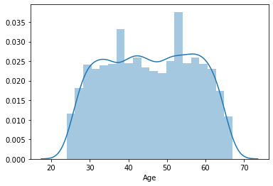

```
Experience distribution diagram
```

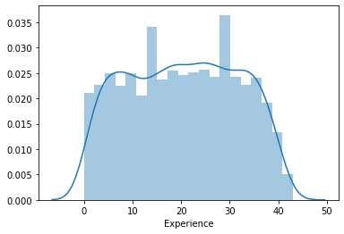

```
Income distribution diagram
```

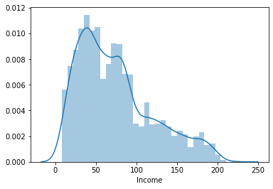

```
CCAvg distribution diagram
```

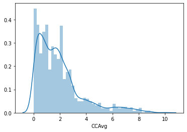

```
Mortgage distribution diagram
```

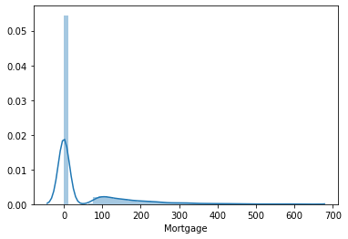

```
Education distribution diagram
```

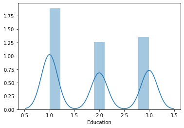

```
Family distribution diagram
```

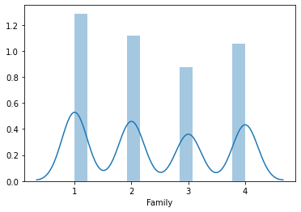

```python
#Univariate plot for all continous columns - Histogram
#Added Education and Family in addition

for col in ['Age','Experience', 'Income', 'CCAvg', 'Mortgage','Education','Family']:
        print(f'{col} distribution diagram')
        sns.distplot(data[col], kde=True)
        plt.show()
```

```
Age box plot
```

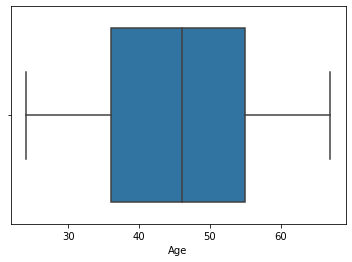

```
Experience box plot
```

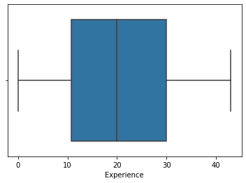

```
Income box plot
```

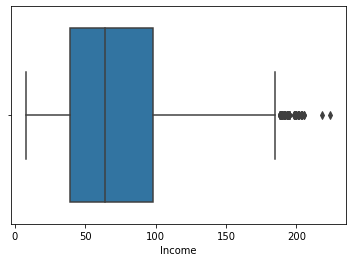

```
CCAvg box plot
```

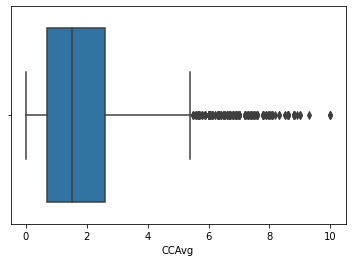

```
Mortgage box plot
```

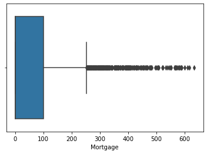

```
Education box plot
```

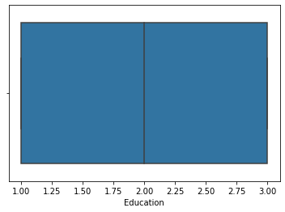

```
Family box plot
```

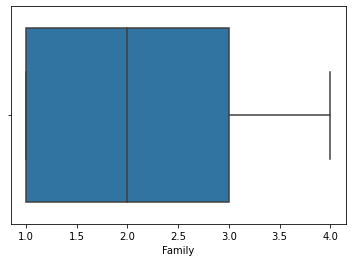

```python
#Univariate box plot for for all continous columns to get better distribution of data - Box Plot
#Added Education and Family in addition

for col in ['Age','Experience', 'Income', 'CCAvg', 'Mortgage','Education','Family']:
        print(f'{col} box plot')
        sns.boxplot(x=data[col])
        plt.show()
```

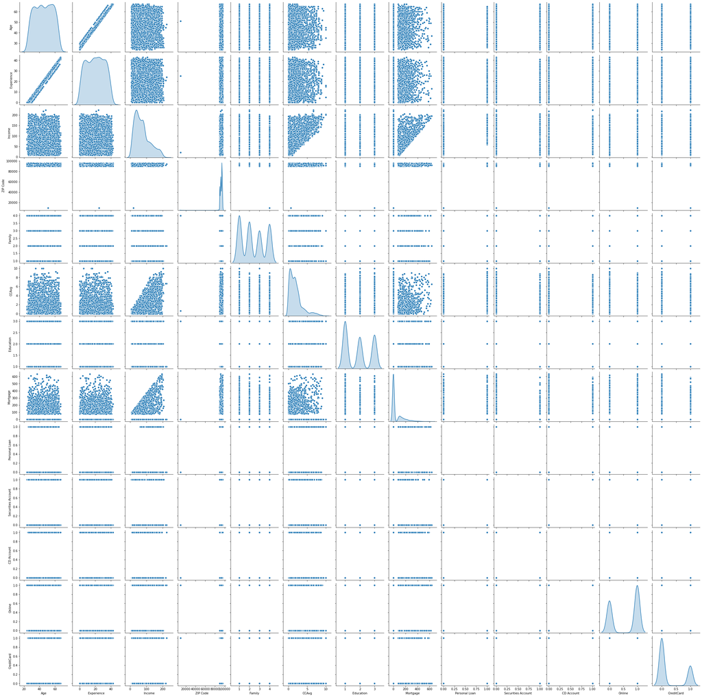

```python
# Bivariate Analysis - using pair plot

cat_columns = ['ID']
sns.pairplot(data.drop(cat_columns, axis=1),diag_kind='kde')
plt.show()
```

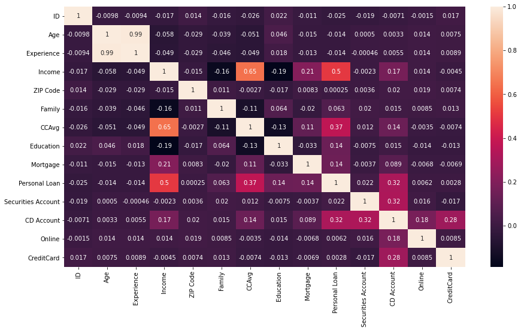

```python
# Using heatmap for bivariate analysis

plt.figure(figsize=(15,8))
sns.heatmap(data.corr(),annot=True)
plt.show()
```

- There seems a strong relation between Age and Experience.
- Family size seems to have very very minor a relation with anything.

#### Get data model ready

```python
# Dropping the columns which doesn't seems of much importance

data_model = data.drop(['ZIP Code', 'ID'], axis=1)

# Performing Manual Hot Encoding to drop Education column
data_model['Education_Undergrad'] = data.apply(lambda x : 1 if x['Education'] == 1 else 0, axis=1)
data_model['Education_Graduate'] = data.apply(lambda x : 1 if x['Education'] == 2 else 0, axis=1)
data_model.drop('Education', axis=1, inplace=True)

data_model.head()
```

|  | Age | Experience | Income | Family | CCAvg | Mortgage | Personal Loan | Securities Account | CD Account | Online | CreditCard | Education_Undergrad | Education_Graduate |
| --- | --- | --- | --- | --- | --- | --- | --- | --- | --- | --- | --- | --- | --- |
| 0 | 25 | 1 | 49 | 4 | 1.60 | 0 | 0 | 1 | 0 | 0 | 0 | 1 | 0 |
| 1 | 45 | 19 | 34 | 3 | 1.50 | 0 | 0 | 1 | 0 | 0 | 0 | 1 | 0 |
| 2 | 39 | 15 | 11 | 1 | 1.00 | 0 | 0 | 0 | 0 | 0 | 0 | 1 | 0 |
| 3 | 35 | 9 | 100 | 1 | 2.70 | 0 | 0 | 0 | 0 | 0 | 0 | 0 | 1 |
| 4 | 35 | 8 | 45 | 4 | 1.00 | 0 | 0 | 0 | 0 | 0 | 1 | 0 | 1 |

### Split the data into training and test set in the ratio of 70:30 respectively (5 marks)

```python
# Importing useful libraries
from sklearn.model_selection import train_test_split
from sklearn.linear_model import LogisticRegression
from sklearn.metrics import roc_curve,auc
from sklearn.metrics import recall_score,classification_report, precision_score, f1_score, accuracy_score, confusion_matrix

#splitting training data set from test data set.
X = data_model.drop('Personal Loan', axis=1)
Y = data_model['Personal Loan']
x_train, x_test, y_train, y_test = train_test_split(X, Y, test_size=0.30,random_state=42)
```

### Use the Logistic Regression model to predict whether the customer will take a personal loan or not. Print all the metrics related to evaluating the model performance (accuracy, recall, precision, f1score, and roc_auc_score). Draw a heatmap to display confusion matrix (15 marks)

```python
regression_model = LogisticRegression(random_state=7,solver='liblinear')
regression_model.fit(x_train, y_train)
```

```
LogisticRegression(random_state=7, solver='liblinear')
```

```python
## defining a function to get confusion matrix in a proper format
def draw_confusion_matrix( actual, predicted ):
    cm = confusion_matrix( actual, predicted)
    sns.heatmap(cm, annot=True,  fmt='.2f', xticklabels = [0,1] , yticklabels = [0,1] )
    plt.ylabel('Observed')
    plt.xlabel('Predicted')
    plt.show()

# defining a function to print out model results
def print_results(regression_model, x_test, y_test, y_predict):
    print("Training accuracy:",regression_model.score(x_train,y_train))
    print()
    print("Testing Accuracy:",regression_model.score(x_test, y_test))
    print()
    print("Recall:",recall_score(y_test,y_predict))
    print()
    print("Precision:",precision_score(y_test,y_predict))
    print()
    print("F1 Score:",f1_score(y_test,y_predict))
    print()
    print("Roc Auc Score:",roc_auc_score(y_test,y_predict))
    print()
    print('Confusion Matrix')
    print(draw_confusion_matrix(y_test,y_predict))

# defining a function to draw area under the curve
def draw_curve(y_test,x_test):
    logit_roc_auc = roc_auc_score(y_test, regression_model.predict(x_test))
    fpr, tpr, thresholds = roc_curve(y_test, regression_model.predict_proba(x_test)[:,1])
    plt.figure()
    plt.plot(fpr, tpr, label='Logistic Regression (area = %0.2f)' % logit_roc_auc)
    plt.plot([0, 1], [0, 1],'r--')
    plt.xlim([0.0, 1.0])
    plt.ylim([0.0, 1.05])
    plt.xlabel('False Positive Rate')
    plt.ylabel('True Positive Rate')
    plt.title('Receiver operating characteristic')
    plt.legend(loc="lower right")
    plt.savefig('Log_ROC')
    plt.show()
```

```
Training accuracy: 0.9555298873808836

Testing Accuracy: 0.9602693602693603

Recall: 0.627906976744186

Precision: 0.8804347826086957

F1 Score: 0.733031674208145

Roc Auc Score: 0.8098974411744528

Confusion Matrix
```

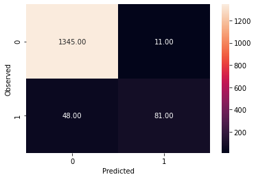

```
None
```

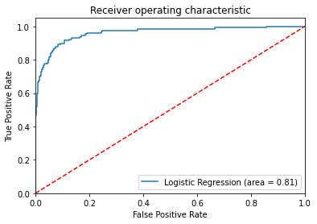

```python
#Getting model Accuracy, Recall, Precision, F-Score, AUC and Confusion Matrix

y_predict = regression_model.predict(x_test)

print_results(regression_model, x_test, y_test, y_predict)

draw_curve(y_test,x_test)
```

### Find out coefficients of all the attributes and show the output in a data frame with column names? For test data show all the rows where the predicted class is not equal to the observed class. (10 marks)

```python
# Coefficients on train data

fi = pd.DataFrame()
fi['Col'] = x_train.columns
fi['Coeff'] = np.round(abs(regression_model.coef_[0]),2)
fi.sort_values(by='Coeff',ascending=False)
```

|  | Col | Coeff |
| --- | --- | --- |
| 10 | Education_Undergrad | 3.79 |
| 7 | CD Account | 3.16 |
| 9 | CreditCard | 0.86 |
| 8 | Online | 0.81 |
| 3 | Family | 0.60 |
| 6 | Securities Account | 0.54 |
| 1 | Experience | 0.29 |
| 0 | Age | 0.28 |
| 11 | Education_Graduate | 0.20 |
| 4 | CCAvg | 0.15 |
| 2 | Income | 0.06 |
| 5 | Mortgage | 0.00 |

```python
# Observe the predicted and observed classes in a dataframe.

z = x_test.copy()
z['Observed Personal Loan'] = y_test
z['Predicted Personal Loan'] = y_predict
#z[z['Predicted Personal Loan Status'] == 1]

# show rows where predicted data != observed data
z[z['Observed Personal Loan'] != z['Predicted Personal Loan']]
```

|  | Age | Experience | Income | Family | CCAvg | Mortgage | Securities Account | CD Account | Online | CreditCard | Education_Undergrad | Education_Graduate | Observed Personal Loan | Predicted Personal Loan |
| --- | --- | --- | --- | --- | --- | --- | --- | --- | --- | --- | --- | --- | --- | --- |
| 4470 | 44 | 20 | 111 | 2 | 5.30 | 0 | 0 | 0 | 1 | 0 | 0 | 1 | 1 | 0 |
| 3605 | 61 | 31 | 130 | 2 | 2.60 | 0 | 0 | 0 | 0 | 0 | 0 | 0 | 1 | 0 |
| 965 | 62 | 36 | 135 | 2 | 5.20 | 0 | 0 | 0 | 1 | 0 | 0 | 1 | 1 | 0 |
| 737 | 64 | 37 | 138 | 2 | 2.80 | 0 | 0 | 0 | 1 | 0 | 0 | 1 | 1 | 0 |
| 2194 | 34 | 9 | 123 | 1 | 1.60 | 0 | 0 | 0 | 1 | 0 | 0 | 1 | 1 | 0 |

### Give conclusion related to the Business understanding of your model? (5 marks)

## 6. Business Understanding of the model

### `Insights`

- Fields like **ID and ZIP** are of not much relavance and doesn't contribute anything in the model
- `Categorical Variables`
  - Credit Card and Online fields do not seems to have much impact on the target variable (Personal Loan)
  - CD Account seems to have a good effect on the target variable (Personal Loan)
  - Securities Account seems to have a minor effect on the target variable (Personal Loan)
  - Education also has a minor effect on the target variable (Personal Loan).
  - Family does have a very minor effect on the target variable.
- `Continuous Variables`
  - Mortgage has a minor effect on the target variable. (Personal Loan)
  - Income has a **strong effect** on the target variable. (Personal Loan)
  - Age and Experience show some minor effect on the target variable (Personal Loan)
  - CCAvg does have an effect on the target variable.

### `Conclusions`

- Accuracy: ~96% (Although accuracy is not always a good measure, we will look at other attributes)
- Type I error = 11 (FP - Customers who were predicted to offer a loan while they didn't actually get it) , Type II error = 48 (FN - Customers who are predicted not to offer a loan while they actually got it)
- Recall (Out of total customers who accepted loan our prediction to offer loan is at): ~63%
- Precision (Out of total customers who were offered loan from our model while people who actually took loan is at): ~88%
- Precision is high and Recall is not that high, still making this a good model as F-Score is: ~73%
- Area under the Curve is ~81% also shows that this is a good model.